# Homework 8

Kaylyn Zipp

4/26/2021

1. Fit an N-mixture model that assumes abundance is a function of wetland size and type, and detection probability is a function of sky and time (5 points).

```r
sosp_mat<-read.csv("sosp_nmix.csv")
library(unmarked)
sosp_mat <- as.matrix(sosp_mat)

p_covs <- read.csv('p_covs_nmix.csv')
det_covs <- list(
time = data.frame(p_covs[, c('time.1', 'time.2')]),
sky = data.frame(sky.1 = factor(p_covs$sky.1),
sky.2 = factor(p_covs$sky.2))

)
site_covs <- read.csv('n_covs_nmix.csv')
head(site_covs)
```

```
##     point type year     size herb shrub1 bareground woody water shrub5
## 1  ks_pc1 acep    0 6.110759    3      1          1     0     1      1
## 2  ks_pc2 acep    0 6.110759    3      1          1     0     0      1
## 3  ks_pc3 acep    0 6.110759    2      1          2     0     0      1
## 4 all_pc1 acep    0 4.241109    2      1          2     0     0      2
## 5 all_pc2 acep    0 4.241109    1      1          2     0     0      1
## 6 cro_pc1 acep    0 3.217254    3      1          2     0     1      1
```

```r
nmix_data <- unmarkedFramePCount(y = sosp_mat, siteCovs = site_covs, obsCovs = det_covs)

fit <- pcount(formula = ~ time + sky ~ size + type, data = nmix_data, K = 100)
```

2. Write a function that calculates the sum of squared Pearson residuals from a fitted model.

```r
Pearson <- function(fit){
  sosp_mat<-read.csv("sosp_nmix.csv")
  sosp_mat<-as.matrix(sosp_mat)
  count<-sosp_mat[,1]
  count2<-sosp_mat[,2]
  obs<-as.matrix(c(rbind(count,count2)))
  prd_a<-predict(object = fit, type = 'state')
  prd_ab<-as.matrix(c(rbind(prd_a$Predicted, prd_a$Predicted)))
  lambda<-prd_ab
  pred_c<-predict(object = fit, type = "det")
  phat<-pred_c$Predicted
  ts<-(obs - (lambda*phat))^2 / (lambda*phat*(1-phat))
  return(sum(ts))

}
Pearson(fit)
```

```
## [1] 1025.856
```

3. Use the parboot() function in R to simulate the distribution of this test statistic under the assumption that your fitted model is the data-generating model. Simulate 1000 values of the test statistic. Note that this may take several minutes (5 points).

```r
sosp_mat<-read.csv("sosp_nmix.csv")
sims <- parboot(object = fit, statistic = Pearson, nsim = 1000, report = 1)
```

```
## t0 = 1025.856
```

```
## Running in parallel on 3 cores. Bootstrapped statistics not reported.
```

```r
sims
```

```
##
## Call: parboot(object = fit, statistic = Pearson, nsim = 1000, report = 1)
##
## Parametric Bootstrap Statistics:
##     t0 mean(t0 - t_B) StdDev(t0 - t_B) Pr(t_B > t0)
## 1 1026          -49.1              104        0.663
##
## t_B quantiles:
##       0% 2.5%  25%  50%  75% 97.5% 100%
## [1,] 870  911 1002 1062 1131  1318 1681
##
## t0 = Original statistic computed from data
## t_B = Vector of bootstrap samples
```

4. Plot the distribution of the simulated test statistic. Include in this plot the value of your test statistic calculated from your fitted model. What is the null hypothesis you are testing when conducting model checking? Do you reject or fail to reject this null hypothesis? What are the implications for how well you model fits the data (5 points)?

Plot of the distribution of the test statistic:

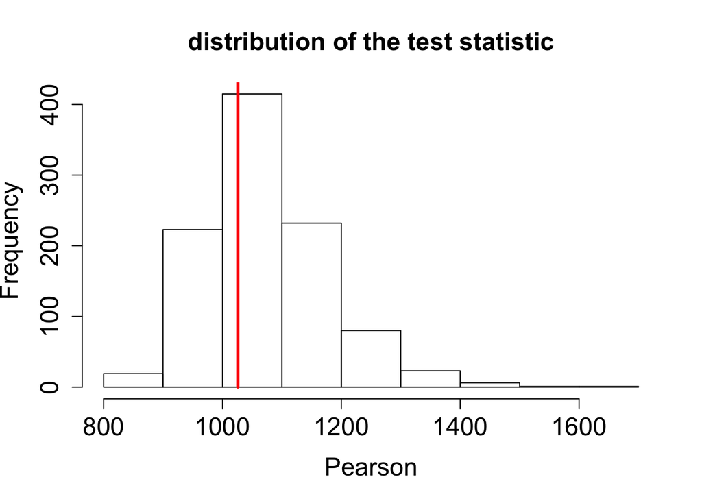

```r
hist(sims@t.star[,1], xlab = 'Pearson', main = 'distribution of the test statistic', cex.axis = 1.5, cex.lab = 1.5, cex.main = 1.5)
lines(x = rep(Pearson(fit), 2),
y = c(0, 1000),
col = 'red', lwd = 3)
```

```r
sum(sims@t.star[,1]>Pearson(fit))/1000
```

```
## [1] 0.664
```

```r
sims
```

```
##
## Call: parboot(object = fit, statistic = Pearson, nsim = 1000, report = 1)
##
## Parametric Bootstrap Statistics:
##     t0 mean(t0 - t_B) StdDev(t0 - t_B) Pr(t_B > t0)
## 1 1026          -49.1              104        0.663
##
## t_B quantiles:
##       0% 2.5%  25%  50%  75% 97.5% 100%
## [1,] 870  911 1002 1062 1131  1318 1681
##
## t0 = Original statistic computed from data
## t_B = Vector of bootstrap samples
```